# Concord_spec_Tommy.With loops

```r
rm(list=ls())

require(stringr)
require(zoo)
require(openair)

source("concord_filter.R")
source("cospectra_plot3.R")

na.count<-function(x) sum(is.na(x))
na.mean<-function(x) ifelse(is.nan(mean(x,na.rm=T)),NA,mean(x,na.rm=T))
```

# Defining the data I/O directory

hc: define all I/O upfront and reuse them for consistency

```r
## change root.path as needed
root.path<-"C:\\Users\\Tommy\\flux\\Data-exploring\\02_Concord\\"
#root.path<-"D:\\Housen\\Flux\\Data-exploring\\02_Concord\\"
eddypro.path<-paste0(root.path,"01_Proccessed_Data\\Master_Eddy\\") ## this is where the EddyPro outputs located
plot.path<-paste0(root.path,"01_Proccessed_Data\\spectrum_plot\\") ## this is where the output plots located

#path_met<-"C:\\Users\\Tommy\\flux\\Data-exploring\\02_Concord\\"
path.in_met<-paste(root.path,"01_Proccessed_Data",sep="")
ver<-"met_data"

# hc: Use this for storing combined file
path.out<-paste(root.path,"03_combined_data\\",sep="")
```

# Define file naming / version used

hc: Keep anything that needs to change regularly here

```r
## use follows to specify the versions of EddyPro outputs
# file name of the master EddyPro file
cdata.file2<-paste0("master_eddy_pro_concord.csv")

## Use follows to define binned spectrum file names
cdata.proc.time<-"2020-04-17T161020"
cdata.proc.ext<-"_adv"
#20190614-1700_binned_cospectra_2020-04-17T161020_adv

## use follows to specify the versions of master met file
file.name<-paste("MET_data_master",sep="")

#"C:\Users\Tommy\flux\Data-exploring\02_Concord\01_Proccessed_Data\Master_Eddy"
#"C:\Users\Tommy\flux\Data-exploring\02_Concord\01_Proccessed_Data\Master_Eddy\master_eddy_pro_concord.csv"
#"C:\Users\Tommy\flux\Data-exploring\02_Concord\01_Proccessed_Data\Master_Eddy\eddypro_binned_cospectra"
#"C:\Users\Tommy\flux\Data-exploring\02_Concord\01_Proccessed_Data\Master_Eddy\eddypro_full_cospectra"
#"C:\Users\Tommy\flux\Data-exploring\02_Concord\01_Proccessed_Data\Master_Eddy\spectrum_plot"
```

# Read in EddyPro fulloutput file

- parse variable names and define N/As
- remove time periods that does not have enough record of high frequency data

```r
## read in full output file
cdata<-read.csv(paste(eddypro.path,cdata.file2,sep=""),
                skip=3,
                header=F,
                na.strings="-9999",
                stringsAsFactors=F)
colnames(cdata)<-colnames(read.csv(paste(eddypro.path,cdata.file2,sep=""),
                                   skip=1,
                                   header=T,
                                   na.strings="NaN"))

cdata<-cdata[cdata$filename!="not_enough_data"&
               !is.na(cdata$used_records),]

head(cdata)
```

|  | filename | date | time | DOY | daytime | file_records | used_records | Tau | qc_Tau | H | qc_H | LE | qc_LE | co2_flux | qc_co2_flux | h2o_flux | qc_h2o_flux | H_strg | LE_strg | co2_strg | h2o_strg | co2_v.adv | h2o_v.adv | co2_molar_density | co2_mole_fraction | co2_mixing_ratio | co2_time_lag | co2_def_timelag | h2o_molar_density | … |
| --- | --- | --- | --- | --- | --- | --- | --- | --- | --- | --- | --- | --- | --- | --- | --- | --- | --- | --- | --- | --- | --- | --- | --- | --- | --- | --- | --- | --- | --- | --- |
| 1 | 2019-06-14T163000_smart3-00177.ghg | 6/14/2019 | 17:00 | 165.7082 | 1 | 18000 | 18000 | -0.336264 | 0 | 254.852 | 0 | 54.9173 | 0 | -3.25927 | 0 | 1.23875 | 0 | NA | NA | NA | NA | -3.92e-11 | -1.32e-12 | 16.8474 | 406.749 | 412.403 | 0 | 0 | 567.815 | … |
| 2 | 2019-06-14T170000_smart3-00177.ghg | 6/14/2019 | 17:30 | 165.7290 | 1 | 18000 | 18000 | -0.291135 | 0 | 270.018 | 0 | 63.3446 | 0 | -3.32627 | 0 | 1.43024 | 0 | 2.50327 | 0.609896 | -0.02730 | 0.01380 | -2.22e-10 | -7.58e-12 | 16.7794 | 406.424 | 412.142 | 0 | 0 | 572.766 | … |
| 3 | 2019-06-14T173000_smart3-00177.ghg | 6/14/2019 | 18:00 | 165.7498 | 1 | 18000 | 18000 | -0.220308 | 0 | 267.061 | 0 | 69.1883 | 0 | -3.08957 | 0 | 1.56332 | 0 | 1.84576 | 0.334318 | -0.02950 | 0.00755 | 2.77e-11 | 9.52e-13 | 16.7234 | 406.071 | 411.821 | 0 | 0 | 575.077 | … |
| 4 | 2019-06-14T180000_smart3-00177.ghg | 6/14/2019 | 18:30 | 165.7707 | 1 | 18000 | 18000 | -0.175547 | 0 | 274.062 | 0 | 80.8935 | 0 | -3.52716 | 0 | 1.83035 | 0 | 3.52689 | 0.872251 | -0.03400 | 0.01970 | -4.79e-11 | -1.68e-12 | 16.6293 | 405.662 | 411.505 | 0 | 0 | 582.152 | … |
| 5 | 2019-06-14T190000_smart3-00177.ghg | 6/14/2019 | 19:30 | 165.8123 | 0 | 18000 | 18000 | -0.110688 | 0 | 299.239 | 0 | 115.8370 | 0 | -2.90573 | 0 | 2.62718 | 0 | NA | NA | NA | NA | -2.97e-11 | -1.08e-12 | 16.5047 | 405.829 | 411.923 | 0 | 0 | 601.682 | … |
| 6 | 2019-06-14T193000_smart3-00177.ghg | 6/14/2019 | 20:00 | 165.8332 | 0 | 18000 | 18000 | -0.159866 | 0 | 318.103 | 0 | 108.8170 | 0 | -3.14684 | 0 | 2.46932 | 0 | 1.35436 | 0.295193 | -0.00913 | 0.00670 | -1.73e-10 | -6.36e-12 | 16.4701 | 405.718 | 411.845 | 0 | 0 | 603.887 | … |

```r
NA
```

# Read in Met data master file

- parse variable names and define N/As, NAN, -7999

```r
met_data_master<-read.csv(paste(path.in_met,"\\",ver,"\\",file.name,".csv",sep=""),
                          header=F,
                          skip=4,
                          na.strings=c("NAN","-7999"),
                          stringsAsFactors = F)
colnames(met_data_master)<-colnames(
  read.csv(paste(path.in_met,"\\",ver,"\\",file.name,".csv",sep=""),
           header=T,
           skip= 1))

head(met_data_master)
```

|  | TIMESTAMP | RECORD | BattV_Avg | PTemp_C_Avg | AM25T_ref_Avg | TC_Avg.1. | TC_Avg.2. | TC_Avg.3. | TC_Avg.4. | TC_Avg.5. | TC_Avg.6. | TC_Avg.7. | TC_Avg.8. | TC_Avg.9. | TC_Avg.10. | TC_Avg.11. | TC_Avg.12. | TC_Avg.13. | TC_Avg.14. | TC_Avg.15. | TC_Avg.16. | TC_Avg.17. | TC_Avg.18. | TC_Avg.19. | TC_Avg.20. | TC_Avg.21. | TC_Avg.22. | TC_Avg.23. | TC_Avg.24. | … |
| --- | --- | --- | --- | --- | --- | --- | --- | --- | --- | --- | --- | --- | --- | --- | --- | --- | --- | --- | --- | --- | --- | --- | --- | --- | --- | --- | --- | --- | --- | --- |
| 1 | 6/25/2019 9:00 | 530 | 19.35 | 24.83 | NA | NA | NA | NA | NA | NA | NA | NA | NA | NA | NA | NA | NA | NA | NA | NA | NA | NA | NA | NA | NA | NA | NA | NA | NA | … |
| 2 | 6/25/2019 9:30 | 531 | 19.35 | 26.16 | NA | NA | NA | NA | NA | NA | NA | NA | NA | NA | NA | NA | NA | NA | NA | NA | NA | NA | NA | NA | NA | NA | NA | NA | NA | … |
| 3 | 6/25/2019 10:00 | 532 | 19.35 | 27.16 | NA | NA | NA | NA | NA | NA | NA | NA | NA | NA | NA | NA | NA | NA | NA | NA | NA | NA | NA | NA | NA | NA | NA | NA | NA | … |
| 4 | 6/25/2019 10:30 | 533 | 19.34 | 27.90 | NA | NA | NA | NA | NA | NA | NA | NA | NA | NA | NA | NA | NA | NA | NA | NA | NA | NA | NA | NA | NA | NA | NA | NA | NA | … |
| 5 | 6/25/2019 11:00 | 534 | 19.34 | 28.61 | NA | NA | NA | NA | NA | NA | NA | NA | NA | NA | NA | NA | NA | NA | NA | NA | NA | NA | NA | NA | NA | NA | NA | NA | NA | … |
| 6 | 6/25/2019 11:30 | 535 | 19.34 | 29.30 | NA | NA | NA | NA | NA | NA | NA | NA | NA | NA | NA | NA | NA | NA | NA | NA | NA | NA | NA | NA | NA | NA | NA | NA | NA | … |

```r
NA
```

# Parsing time stamp of cdata (EddyPro file)

- converting it into a POSIXlt vector*
- interpreting date and time into new timestamp column
- Then taking that time stamp column and turning each time into a unique number (time.id) so I can join based on that. As it can be really tricky to join/merge based on time stamps alone**
- Or I could make sure both time stamps are characters and match them that way**
- Finally ploting time.id to make sure my times translate linearily*

```r
cdata$TIMESTAMP<-strptime(paste(cdata$date,cdata$time,sep=" "),
                          format="%m/%d/%Y %H:%M",
                          tz = "Etc/GMT-8")

#cdata$TIMESTAMP=cdata$TIMESTAMP+1800 don't need to add 1800. already in endtime format
#cdata$TIMESTAMP=cdata$TIMESTAMP #just rename it end. so that we know

cdata$time.id<-cdata$TIMESTAMP$year+1900+
  (cdata$TIMESTAMP$yday)/366+
  (cdata$TIMESTAMP$hour)/366/24+
  (cdata$TIMESTAMP$min)/366/24/60

cdata$time.id[1:50]
```

```
 [1] 2019.450 2019.450 2019.450 2019.450 2019.450 2019.450 2019.450 2019.450 2019.451
[10] 2019.451 2019.451 2019.451 2019.451 2019.451 2019.451 2019.451 2019.451 2019.452
[19] 2019.452 2019.452 2019.452 2019.452 2019.452 2019.452 2019.452 2019.452 2019.452
[28] 2019.452 2019.452 2019.452 2019.452 2019.452 2019.452 2019.453 2019.453 2019.453
[37] 2019.453 2019.453 2019.453 2019.453 2019.453 2019.453 2019.453 2019.453 2019.453
[46] 2019.453 2019.454 2019.454 2019.454 2019.454
```

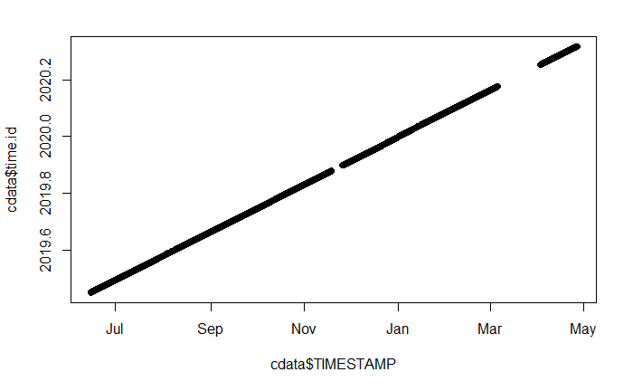

```r
plot(cdata$TIMESTAMP,cdata$time.id)
```

```r
which(duplicated(cdata$time.id))
```

```
integer(0)
```

# Parsing time stamp of cdata (Met file)

- Taking the met_data and turning the time stamp into posixt format#
- creating a time id for the MET Data so I I can join the MET and Eddy Pro Data#

```r
met_data_master$TIMESTAMP<-strptime(met_data_master$TIMESTAMP,
                                    format ="%m/%d/%Y %H:%M",
                                    tz = "Etc/GMT-8")

met_data_master$time.id <-met_data_master$TIMESTAMP$year+1900+
  (met_data_master$TIMESTAMP$yday)/366+
  (met_data_master$TIMESTAMP$hour)/366/24+
  (met_data_master$TIMESTAMP$min)/366/24/60

met_data_master$time.id[1:20]
```

```
 [1] 2019.479 2019.479 2019.479 2019.479 2019.479 2019.479 2019.480 2019.480 2019.480
[10] 2019.480 2019.480 2019.480 2019.480 2019.480 2019.480 2019.480 2019.480 2019.480
[19] 2019.480 2019.480
```

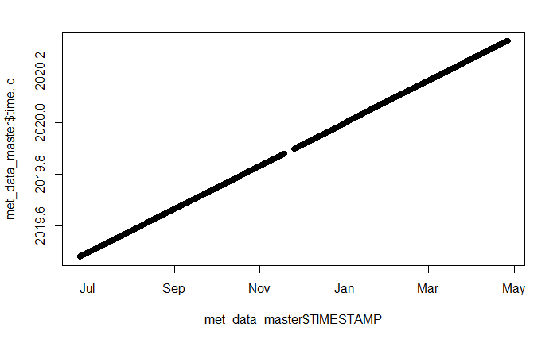

```r
plot(met_data_master$TIMESTAMP,met_data_master$time.id)
```

```r
which(duplicated(met_data_master$time.id))
```

```
integer(0)
```

```r
head(met_data_master)
```

|  | TIMESTAMP | RECORD | BattV_Avg | PTemp_C_Avg | AM25T_ref_Avg | TC_Avg.1. | TC_Avg.2. | TC_Avg.3. | TC_Avg.4. | TC_Avg.5. | TC_Avg.6. | TC_Avg.7. | TC_Avg.8. | TC_Avg.9. | TC_Avg.10. | TC_Avg.11. | TC_Avg.12. | TC_Avg.13. | TC_Avg.14. | TC_Avg.15. | TC_Avg.16. | TC_Avg.17. | TC_Avg.18. | TC_Avg.19. | TC_Avg.20. | TC_Avg.21. | TC_Avg.22. | TC_Avg.23. | TC_Avg.24. | … |
| --- | --- | --- | --- | --- | --- | --- | --- | --- | --- | --- | --- | --- | --- | --- | --- | --- | --- | --- | --- | --- | --- | --- | --- | --- | --- | --- | --- | --- | --- | --- |
| 1 |  | 530 | 19.35 | 24.83 | NA | NA | NA | NA | NA | NA | NA | NA | NA | NA | NA | NA | NA | NA | NA | NA | NA | NA | NA | NA | NA | NA | NA | NA | NA | … |
| 2 |  | 531 | 19.35 | 26.16 | NA | NA | NA | NA | NA | NA | NA | NA | NA | NA | NA | NA | NA | NA | NA | NA | NA | NA | NA | NA | NA | NA | NA | NA | NA | … |
| 3 |  | 532 | 19.35 | 27.16 | NA | NA | NA | NA | NA | NA | NA | NA | NA | NA | NA | NA | NA | NA | NA | NA | NA | NA | NA | NA | NA | NA | NA | NA | NA | … |
| 4 |  | 533 | 19.34 | 27.90 | NA | NA | NA | NA | NA | NA | NA | NA | NA | NA | NA | NA | NA | NA | NA | NA | NA | NA | NA | NA | NA | NA | NA | NA | NA | … |
| 5 |  | 534 | 19.34 | 28.61 | NA | NA | NA | NA | NA | NA | NA | NA | NA | NA | NA | NA | NA | NA | NA | NA | NA | NA | NA | NA | NA | NA | NA | NA | NA | … |
| 6 |  | 535 | 19.34 | 29.30 | NA | NA | NA | NA | NA | NA | NA | NA | NA | NA | NA | NA | NA | NA | NA | NA | NA | NA | NA | NA | NA | NA | NA | NA | NA | … |

```r
#met_data_master$TIMESTAMP[1:20]
```